# Re-analysis of Azhar et al.

Ian Hussey & Martin Plöderl

24 February, 2026

# Info

Paper here: https://www.sciencedirect.com/science/article/pii/S0165032725024978?via%3Dihub

PubPeer comments: https://pubpeer.com/publications/799F60D117E44BAEE391AC93A216D2#1

# Dependencies

```r
# dependencies
library(esc)
library(readxl)
library(effsize)
library(dplyr)
library(tidyverse)
library(knitr)
library(kableExtra)
library(effectsize)
library(roundwork)

print_nice_table <- function(dat){
  dat |>
    kable() |>
    kable_classic(full_width = FALSE)
}
```

# Participant level data

Shared with Martin 05.02.2026 from JAD, Delbello, Melissa (DELBELMP@UCMAIL.UC.EDU)

There are two data-sheets, one seems to be the raw data (“scales C,I”), hereafter referred to as “raw”, and the other one was used for calculation of statistical results (“data for statstics” [sic]), hereafter referred to as “stats”.

We cleaned data with “processing.Rmd”.

# Direct comparisons

```r
sheet_raw <- read_csv("../data/processed/data_processed_sheet_raw.csv")
sheet_stats <- read_csv("../data/processed/data_processed_sheet_stats.csv")

sheets_combined <- read_csv("../data/processed/data_processed_combined.csv")
```

## Define which columns to compare

We compare only columns present in BOTH harmonised datasets.

```r
numeric_vars <- c(
  # Baseline
  "stress_baseline", "depression_baseline", "anxiety_baseline", "emq_baseline",
  # Follow-up
  "stress_followup", "depression_followup", "anxiety_followup", "emq_followup"
)
```

## Quantify numeric differences

```r
compare_numeric <- function(var) {
  d <- sheet_raw[[var]]
  s <- sheet_stats[[var]]

  tibble(
    variable      = var,
    n             = sum(!is.na(d) & !is.na(s)),
    n_exact_match = sum(d == s, na.rm = TRUE),
    pct_match     = round(100 * n_exact_match / n, 1),
    mean_diff     = round(mean(d - s, na.rm = TRUE), 2),
    sd_diff       = round(sd(d - s, na.rm = TRUE), 2),
    min_diff      = min(d - s, na.rm = TRUE),
    max_diff      = max(d - s, na.rm = TRUE),
    correlation   = round(cor(d, s, use = "complete.obs"), 4)
  )
}

numeric_comparison <- map_dfr(numeric_vars, compare_numeric)

numeric_comparison |>
  print_nice_table()
```

| variable | n | n_exact_match | pct_match | mean_diff | sd_diff | min_diff | max_diff | correlation |
| --- | --- | --- | --- | --- | --- | --- | --- | --- |
| stress_baseline | 64 | 64 | 100.0 | 0.00 | 0.00 | 0 | 0 | 1.0000 |
| depression_baseline | 64 | 62 | 96.9 | 0.08 | 0.91 | -2 | 7 | 0.9292 |
| anxiety_baseline | 64 | 64 | 100.0 | 0.00 | 0.00 | 0 | 0 | 1.0000 |
| emq_baseline | 64 | 0 | 0.0 | -25.61 | 17.83 | -76 | 15 | 0.3328 |
| stress_followup | 64 | 14 | 21.9 | 0.61 | 6.85 | -20 | 16 | 0.6046 |
| depression_followup | 64 | 20 | 31.2 | 1.31 | 4.90 | -10 | 11 | 0.4331 |
| anxiety_followup | 64 | 19 | 29.7 | 0.80 | 4.93 | -11 | 13 | 0.2439 |
| emq_followup | 64 | 0 | 0.0 | -22.11 | 18.34 | -76 | 27 | 0.2822 |

## Row-level detail for discrepant numeric variables

For any variable with < 100% match, show which rows differ.

```r
discrepant_vars <- numeric_comparison |>
  filter(pct_match < 100) |>
  pull(variable)

row_diffs <- map_dfr(discrepant_vars, \(var) {
  tibble(
    variable   = var,
    row        = 1:nrow(sheet_raw),
    group      = sheet_raw$group,
    raw_value = sheet_raw[[var]],
    stats_value = sheet_stats[[var]],
    difference = sheet_raw[[var]] - sheet_stats[[var]]
  ) |>
    filter(difference != 0 | is.na(difference))
})

# Summarise by variable and direction
row_diffs |>
  group_by(variable, group) |>
  summarise(
    n_discrepant  = n(),
    #n_raw_higher = sum(difference > 0, na.rm = TRUE),
    #n_stats_higher = sum(difference < 0, na.rm = TRUE),
    mean_diff = mean(difference, na.rm = TRUE),
    .groups = "drop"
  ) |>
  print_nice_table()
```

| variable | group | n_discrepant | mean_diff |
| --- | --- | --- | --- |
| anxiety_followup | omega | 31 | 3.645161 |
| anxiety_followup | placebo | 14 | -4.428571 |
| depression_baseline | placebo | 2 | 2.500000 |
| depression_followup | omega | 28 | 5.000000 |
| depression_followup | placebo | 16 | -3.500000 |
| emq_baseline | omega | 32 | -26.156250 |
| emq_baseline | placebo | 32 | -25.062500 |
| emq_followup | omega | 32 | -17.968750 |
| emq_followup | placebo | 32 | -26.250000 |
| stress_followup | omega | 31 | 5.709677 |
| stress_followup | placebo | 19 | -7.263158 |

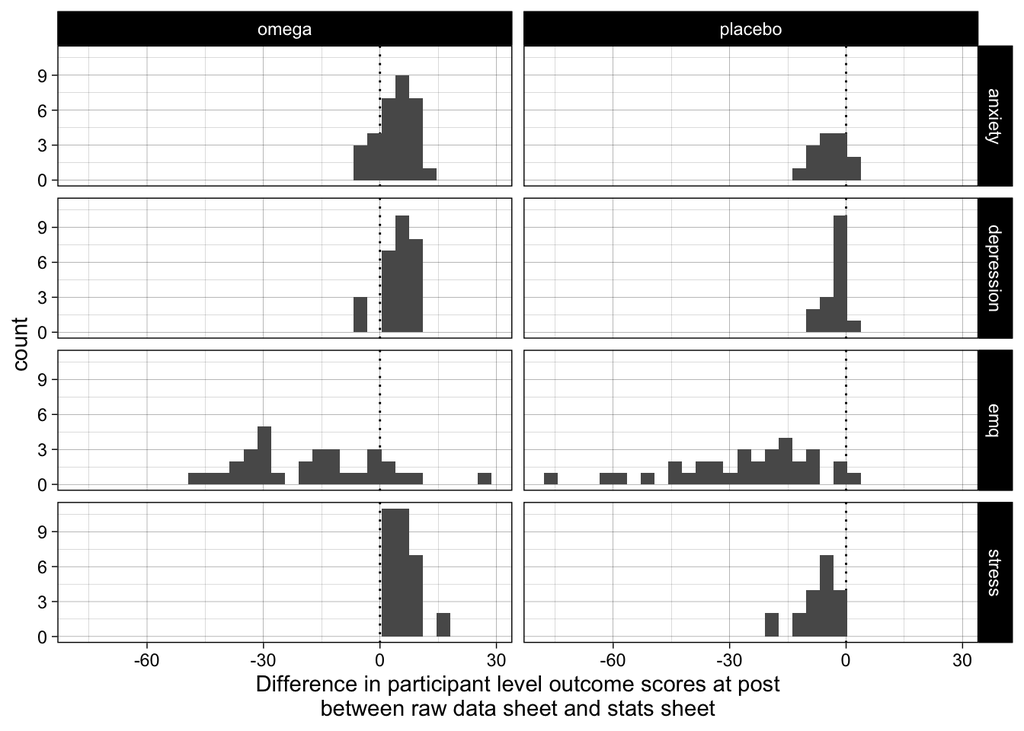

```r
row_diffs |>
  separate(variable, into = c("outcome", "timepoint"), sep = "_") |>
  filter(timepoint == "followup") |>
  ggplot(aes(difference)) +
  geom_vline(xintercept = 0, linetype = "dotted") +
  geom_histogram() +
  theme_linedraw() +
  facet_grid(outcome ~ group) +
  xlab("Difference in participant level outcome scores at post\nbetween raw data sheet and stats sheet")
```

Total discrepant cells: 269

## Flag pattern: baseline vs follow-up agreement

```r
numeric_comparison |>
  filter(!variable %in% c("age", "sex", "depression_medication",
                           "diseases", "weight", "height")) |>
  mutate(
    timepoint = if_else(str_detect(variable, "followup"), "follow-up", "baseline"),
    scale     = str_remove(variable, "_(baseline|followup)")
  ) |>
  select(scale, timepoint, n_exact_match, pct_match, correlation) |>
  pivot_wider(
    names_from  = timepoint,
    values_from = c(n_exact_match, pct_match, correlation),
    names_glue  = "{timepoint}_{.value}"
  ) |>
  select(scale,
         baseline_pct_match, `follow-up_pct_match`,
         baseline_correlation, `follow-up_correlation`) |>
  print_nice_table()
```

| scale | baseline_pct_match | follow-up_pct_match | baseline_correlation | follow-up_correlation |
| --- | --- | --- | --- | --- |
| stress | 100.0 | 21.9 | 1.0000 | 0.6046 |
| depression | 96.9 | 31.2 | 0.9292 | 0.4331 |
| anxiety | 100.0 | 29.7 | 1.0000 | 0.2439 |
| emq | 0.0 | 0.0 | 0.3328 | 0.2822 |

## Save full row-level differences

```r
write_csv(row_diffs, "../data/processed/results_row_level_differences.csv")
write_csv(numeric_comparison, "../data/outputs/results_numeric_comparison_summary.csv")
```

## Plots

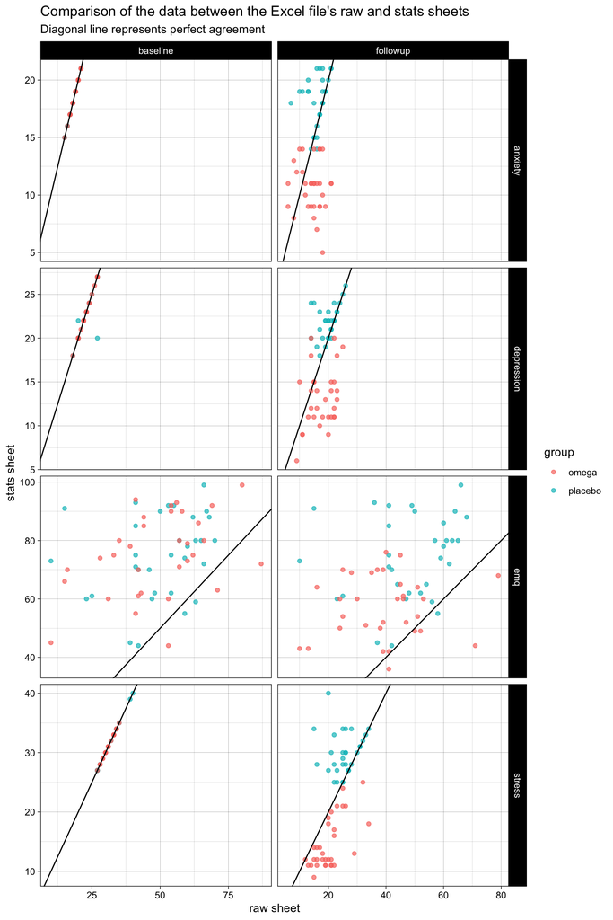

```r
sheets_combined_outcomes <- sheets_combined |>
  select(id = row, group, contains("_followup_"), contains("_baseline_")) |>
  select(!contains("_cat_")) |>
  pivot_longer(cols = c(-id, -group),
               names_to = c("outcome", "timepoint", "source"),
               names_sep = "_",
               values_to = "value") |>
  pivot_wider(names_from = "source",
              values_from = "value") |>
  filter(outcome %in% c("stress",
                        "depression",
                        "anxiety",
                        "emq"))


ggplot(sheets_combined_outcomes, aes(raw, stat, color = group)) +
  geom_point(alpha = 0.7) +
  geom_abline(slope = 1, intercept = 0) +
  theme_linedraw() +
  #coord_fixed() +
  facet_grid(outcome ~ timepoint, scales = "free") +
  xlab("raw sheet") +
  ylab("stats sheet") +
  labs(title = "Comparison of the data between the Excel file's raw and stats sheets",
       subtitle = "Diagonal line represents perfect agreement")
```

```r
ggsave("../data/outputs/differences_between_sheets_ipd_outcomes.png", width = 8, height = 12)
```

Note that scores between the two sheets were previously matched on their row number, age, gender, and study condition; therefore differences between sheets cannot be due to the result of rearranging row order between them. (Matching not done here to allow us to work with anonymized data)

## Summary stats

### From article

```r
summary_table_from_article <- tribble(
  ~outcome, ~timepoint, ~placebo_mean_error, ~omega_mean_error,
  "PSS",    "Before",   "30.81 ± 3.51",   "30.78 ± 1.99",
  "PSS",    "After",    "29.81 ± 0.61",   "14.66 ± 0.79",
  "GAD-7",  "Before",   "18.19 ± 1.89",   "18.81 ± 1.55",
  "GAD-7",  "After",    "18.09 ± 0.37",   "10.68 ± 0.54",
  "PHQ-9",  "Before",   "22.50 ± 2.45",   "22.50 ± 2.37",
  "PHQ-9",  "After",    "21.78 ± 0.33",   "13.19 ± 0.59",
  "EMQ",    "Before",   "74.81 ± 14.20",   "75.35 ± 14.10",
  "EMQ",    "After",    "74.28 ± 2.54",   "57.03 ± 1.96"
)

summary_table_from_article |>
  print_nice_table()
```

| outcome | timepoint | placebo_mean_error | omega_mean_error |
| --- | --- | --- | --- |
| PSS | Before | 30.81 ± 3.51 | 30.78 ± 1.99 |
| PSS | After | 29.81 ± 0.61 | 14.66 ± 0.79 |
| GAD-7 | Before | 18.19 ± 1.89 | 18.81 ± 1.55 |
| GAD-7 | After | 18.09 ± 0.37 | 10.68 ± 0.54 |
| PHQ-9 | Before | 22.50 ± 2.45 | 22.50 ± 2.37 |
| PHQ-9 | After | 21.78 ± 0.33 | 13.19 ± 0.59 |
| EMQ | Before | 74.81 ± 14.20 | 75.35 ± 14.10 |
| EMQ | After | 74.28 ± 2.54 | 57.03 ± 1.96 |

### ± SD

```r
sheets_combined_outcomes_for_es <- sheets_combined |>
  select(id = row, group, contains("_followup_"), contains("_baseline_")) |>
  select(!contains("_cat_")) |>
  pivot_longer(cols = c(-id, -group),
               names_to = c("outcome", "timepoint", "source"),
               names_sep = "_",
               values_to = "score") |>
  filter(outcome %in% c("stress",
                        "depression",
                        "anxiety",
                        "emq")) |>
  mutate(source = case_when(source == "raw" ~ "raw sheet",
                            source == "stat" ~ "stats sheet"))

sheets_combined_outcomes_for_es %>%
  group_by(outcome, timepoint, group, source) %>%
  summarise(mean = mean(score),
            sd = sd(score),
            n = n()) |>
  mutate(across(where(is.numeric), ~ sprintf("%.2f", .x))) |>
  mutate(string_sd = paste(mean, "±", sd)) |>
  select(outcome, timepoint, group, source, string_sd) |>
  pivot_wider(names_from = c(group, source),
              values_from = string_sd) |>
  select(outcome, timepoint, placebo_raw = `placebo_raw sheet`, omega_raw = `omega_raw sheet`, placebo_stats    = `placebo_stats sheet`, omega_stats = `omega_stats sheet`) |>
  mutate(outcome = case_when(outcome == "anxiety" ~ "GAD-7",
                             outcome == "depression" ~ "PHQ-9",
                             outcome == "stress" ~ "PSS",
                             outcome == "emq" ~ "EMQ"),
         outcome = factor(outcome, levels = c("PSS", "GAD-7", "PHQ-9", "EMQ"))) |>
  arrange(outcome) |>
  print_nice_table()
```

| outcome | timepoint | placebo_raw | omega_raw | placebo_stats | omega_stats |
| --- | --- | --- | --- | --- | --- |
| PSS | baseline | 30.81 ± 3.51 | 30.97 ± 1.99 | 30.81 ± 3.51 | 30.97 ± 1.99 |
| PSS | followup | 25.53 ± 4.52 | 20.19 ± 5.15 | 29.84 ± 3.46 | 14.66 ± 4.35 |
| GAD-7 | baseline | 18.19 ± 1.89 | 18.81 ± 1.55 | 18.19 ± 1.89 | 18.81 ± 1.55 |
| GAD-7 | followup | 16.16 ± 3.06 | 14.22 ± 4.00 | 18.09 ± 2.07 | 10.69 ± 2.25 |
| PHQ-9 | baseline | 22.66 ± 2.57 | 22.50 ± 2.37 | 22.50 ± 2.45 | 22.50 ± 2.37 |
| PHQ-9 | followup | 20.03 ± 2.93 | 17.59 ± 4.44 | 21.78 ± 1.84 | 13.22 ± 3.35 |
| EMQ | baseline | 49.75 ± 15.44 | 48.91 ± 17.91 | 74.81 ± 14.27 | 75.06 ± 14.10 |
| EMQ | followup | 48.03 ± 14.82 | 39.28 ± 14.82 | 74.28 ± 14.39 | 57.25 ± 10.78 |

### ± SE

```r
sheets_combined_outcomes_for_es %>%
  group_by(outcome, timepoint, group, source) %>%
  summarise(mean = mean(score),
            se = plotrix::std.error(score),
            n = n()) |>
  mutate(across(where(is.numeric), ~ sprintf("%.2f", .x))) |>
  mutate(string_se = paste(mean, "±", se)) |>
  select(outcome, timepoint, group, source, string_se) |>
  pivot_wider(names_from = c(group, source),
              values_from = string_se) |>
  select(outcome, timepoint, placebo_raw = `placebo_raw sheet`, omega_raw = `omega_raw sheet`, placebo_stats    = `placebo_stats sheet`, omega_stats = `omega_stats sheet`) |>
  mutate(outcome = case_when(outcome == "anxiety" ~ "GAD-7",
                             outcome == "depression" ~ "PHQ-9",
                             outcome == "stress" ~ "PSS",
                             outcome == "emq" ~ "EMQ"),
         outcome = factor(outcome, levels = c("PSS", "GAD-7", "PHQ-9", "EMQ"))) |>
  arrange(outcome) |>
  print_nice_table()
```

| outcome | timepoint | placebo_raw | omega_raw | placebo_stats | omega_stats |
| --- | --- | --- | --- | --- | --- |
| PSS | baseline | 30.81 ± 0.62 | 30.97 ± 0.35 | 30.81 ± 0.62 | 30.97 ± 0.35 |
| PSS | followup | 25.53 ± 0.80 | 20.19 ± 0.91 | 29.84 ± 0.61 | 14.66 ± 0.77 |
| GAD-7 | baseline | 18.19 ± 0.33 | 18.81 ± 0.27 | 18.19 ± 0.33 | 18.81 ± 0.27 |
| GAD-7 | followup | 16.16 ± 0.54 | 14.22 ± 0.71 | 18.09 ± 0.37 | 10.69 ± 0.40 |
| PHQ-9 | baseline | 22.66 ± 0.45 | 22.50 ± 0.42 | 22.50 ± 0.43 | 22.50 ± 0.42 |
| PHQ-9 | followup | 20.03 ± 0.52 | 17.59 ± 0.79 | 21.78 ± 0.33 | 13.22 ± 0.59 |
| EMQ | baseline | 49.75 ± 2.73 | 48.91 ± 3.17 | 74.81 ± 2.52 | 75.06 ± 2.49 |
| EMQ | followup | 48.03 ± 2.62 | 39.28 ± 2.62 | 74.28 ± 2.54 | 57.25 ± 1.91 |

Conclusion:

- Neither the raw nor stats sheets can reproduce the means and ± terms reported in the article’s table 3.
- There is greater match between the means in Table 3 and those calculated from the stats sheet than the raw sheet. However, the stats sheet’s sum scores do not match the raw data, as shown above.
- The ± likely represent a mix of SEs and SDs.

## Cohen’s d

```r
results <- sheets_combined_outcomes_for_es %>%
  mutate(group = factor(group, levels = c("placebo", "omega"))) |>
  group_by(outcome, timepoint, source) %>%
  group_modify(~ effectsize::cohens_d(score ~ group, data = .x)) |>
  select(outcome, timepoint, cohens_d = Cohens_d, cohens_d_ci_lower = CI_low, cohens_d_ci_upper = CI_high) |>
  mutate(outcome = forcats::fct_relevel(outcome, "depression", "anxiety", "stress", "emq")) |>
  arrange(outcome)

results |>
  mutate_if(is.numeric, round, digits = 2) |>
  print_nice_table()
```

| source | outcome | timepoint | cohens_d | cohens_d_ci_lower | cohens_d_ci_upper |
| --- | --- | --- | --- | --- | --- |
| raw sheet | anxiety | baseline | -0.36 | -0.85 | 0.13 |
| stats sheet | anxiety | baseline | -0.36 | -0.85 | 0.13 |
| raw sheet | anxiety | followup | 0.54 | 0.04 | 1.04 |
| stats sheet | anxiety | followup | 3.43 | 2.64 | 4.20 |
| raw sheet | depression | baseline | 0.06 | -0.43 | 0.55 |
| stats sheet | depression | baseline | 0.00 | -0.49 | 0.49 |
| raw sheet | depression | followup | 0.65 | 0.14 | 1.15 |
| stats sheet | depression | followup | 3.17 | 2.42 | 3.90 |
| raw sheet | emq | baseline | 0.05 | -0.44 | 0.54 |
| stats sheet | emq | baseline | -0.02 | -0.51 | 0.47 |
| raw sheet | emq | followup | 0.59 | 0.09 | 1.09 |
| stats sheet | emq | followup | 1.34 | 0.79 | 1.88 |
| raw sheet | stress | baseline | -0.05 | -0.54 | 0.44 |
| stats sheet | stress | baseline | -0.05 | -0.54 | 0.44 |
| raw sheet | stress | followup | 1.10 | 0.57 | 1.63 |
| stats sheet | stress | followup | 3.86 | 3.02 | 4.70 |

```r
results |>
  select(source, outcome, timepoint, cohens_d) |>
  pivot_wider(names_from = source,
              values_from = cohens_d) |>
  janitor::clean_names() |>
  mutate(cohens_d_stats_percent_of_raw = round_up(stats_sheet / raw_sheet * 100, 1)) |>
  mutate_if(is.numeric, round, digits = 2) |>
  print_nice_table()
```

| outcome | timepoint | raw_sheet | stats_sheet | cohens_d_stats_percent_of_raw |
| --- | --- | --- | --- | --- |
| anxiety | baseline | -0.36 | -0.36 | 100.0 |
| anxiety | followup | 0.54 | 3.43 | 629.6 |
| depression | baseline | 0.06 | 0.00 | 0.0 |
| depression | followup | 0.65 | 3.17 | 489.3 |
| emq | baseline | 0.05 | -0.02 | -34.9 |
| emq | followup | 0.59 | 1.34 | 226.8 |
| stress | baseline | -0.05 | -0.05 | 100.0 |
| stress | followup | 1.10 | 3.86 | 350.6 |

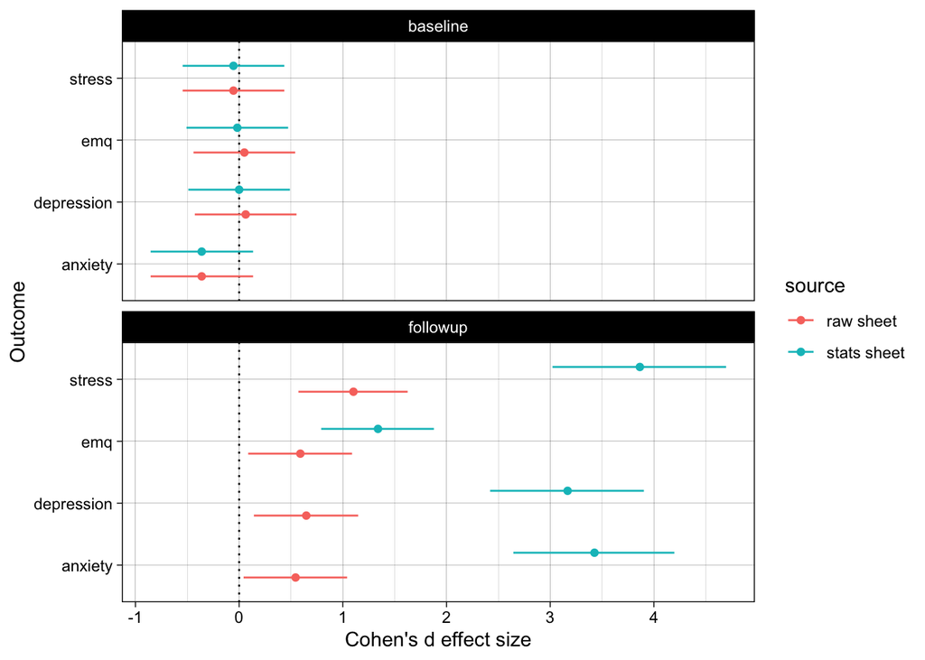

```r
ggplot(results, aes(cohens_d, outcome, color = source)) +
  geom_vline(xintercept = 0, linetype = "dotted") +
  geom_point(position = position_dodge(width = 0.8)) +
  ggstance::geom_linerangeh(aes(xmin = cohens_d_ci_lower, xmax = cohens_d_ci_upper),
                            position = position_dodge(width = 0.8)) +
  theme_linedraw() +
  xlab("Cohen's d effect size") +
  ylab("Outcome") +
  facet_wrap(~ timepoint, ncol = 1)
```

```r
ggsave("../data/outputs/differences_between_sheets_cohens_d.png", width = 6, height = 4)
```

The Cohen’s d values do not match those reported in the article’s Table 3.

The values recalculated from the stats sheet are much closer than those from the raw sheet.

However, the stats sheet’s sum scores do not match the raw data, as shown above.